# An Orrery of Errors

Tahir Enes Gedik

2021-06-17

This is the subtitle of a book by E.P. Thompson, *The Poverty of Theory*. Once upon a time (over 40 years ago), British Marxists were debating about structuralism. Those were high times of Althusser’s influence on Marxism in Europe. Thompson penned this polemical book against Structural Marxism championed by Althusser. The funny thing is that he really used figures of machines to illustrate his point:

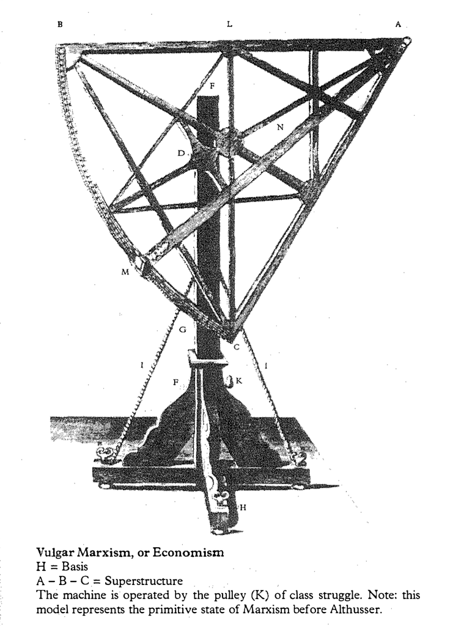

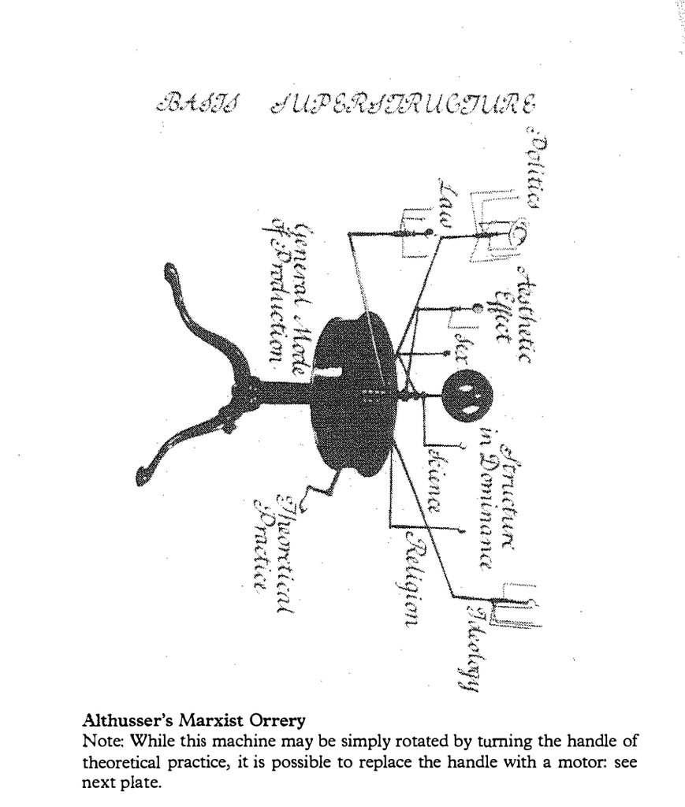

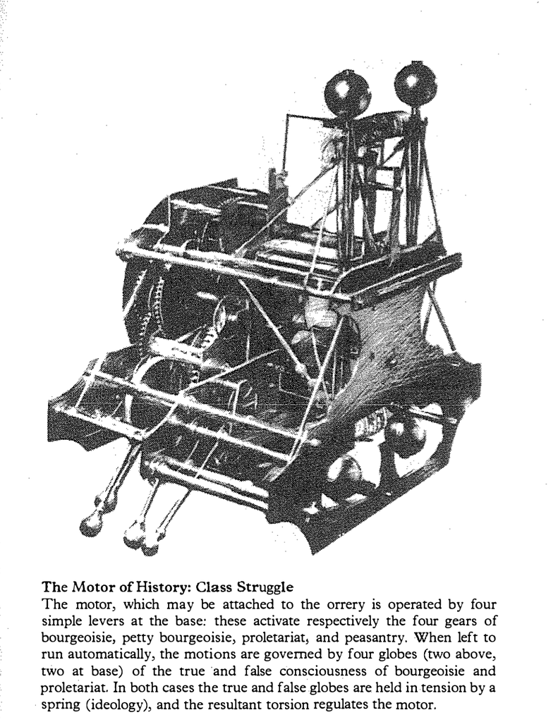

There is no question that Thompson is a witty person. You might disagree with him but still enjoy the prose:

> We might define the present situation more precisely if we employed a category found frequently in Marx’s correspondence with Engels, but a category which evaded Althusser’s vigilant symptomatic scrutiny. All this ‘shit’ (*Geschichtenscheissenschlopff*$^*$), in which both bourgeois sociology and Marxist structuralism stand up to their chins (Dahrendorf beside Poulantzas, modernization theory beside theoretical practice) has been shat upon as by conceptual paralysis, by the de-historicising of process, and by reducing class, ideology, social formations, and almost everything else, to categorical stasis. The sociological section: the elaborate differential rotations within the closure of the orrery; the self-extrapolating programmed developmental series; the mildly disequilibrated equilibrium models, in which dissensus strays unhappily down strange corridors, searching for a reconciliation with consensus; the systems-analyses and structuralisms, with their torques and their combinatories; the counter-factual fictions; the econometric and cleometric groovers - all of these theories hobble along programmed routes from one static category to the next. And all of them are *Geschichtenscheissenschlopff*, unhistorical shit.$^1$

> The text is full of such sarcastic comments.

> $^*$ Not a real word.

$^1$ Thompson, E.P. 1978. *The Poverty of Theory*

As you can see, structuralist and functionalist sociology of the era couldn’t escape from his criticism either.

[Back to nether](https://tegedik.github.io/nw/)